# Forecasting and Time Series Methods Notes 9

[Xiaorui Zhu](https://homepages.uc.edu/~zhuxr/) (zhuxr@mail.uc.edu)

```r
# Install necessary packages
list_packages <- c("AER", "dynlm", "tidyverse", "fpp", "fpp2",
                   "forecast", "readxl", "stargazer", "scales",
                   "quantmod", "urca", "vars", "tseries", "sarima")
new_packages <- list_packages[!(list_packages %in% installed.packages()[,"Package"])]
if(length(new_packages)) install.packages(new_packages)

# Load necessary packages
lapply(list_packages, require, character.only = TRUE)
```

# 1 Orders of Integration

When a time series $Z_t$ has a unit autoregressive root, $Z_t$ is integrated of order one. This is often denoted by $Z_t \sim I(1)$. We simply say that $Z_t$ is $I(1)$. If $Z_t$ is $I(1)$, its first difference $\nabla Z_t$ is stationary.

$Z_t$ is $I(2)$ when $Z_t$ needs to be differenced twice in order to obtain a stationary series. Using the notation introduced here, if $Z_t$ is $I(2)$, its first difference $\nabla Z_t$ is $I(1)$ and its second difference $\nabla^2 Z_t$ is stationary. $Z_t$ is $I(d)$ when $Z_t$ must be differenced $d$ times to obtain a stationary series.

When $Z_t$ is stationary, it is integrated of order 0 so $Z_t$ is $I(0)$.

# 2 Cointegration

When $Z_t$ and $Y_t$ are $I(1)$ and if there is a $\theta$ such that $Y_t-\theta Z_t$ is $I(0)$, $Z_t$ and $Y_t$ are cointegrated. Put differently, cointegration of $Z_t$ and $Y_t$ means that $Z_t$ and $Y_t$ have the same or a common stochastic trend and that this trend can be eliminated by taking a specific difference of the series such that the resulting series is stationary.

R functions for cointegration analysis are implemented in the package `urca`.

It is fairly easy to obtain differences of time series in R. For example, the function `diff()` returns suitably lagged and iterated differences of numeric vectors, matrices and time series objects of the class ts.

Two series are cointegrated when their trends are not too far apart and are in some sense similar. This vague statement, though, can be made precise by conducting a cointegration test, which tests whether the residuals from regressing one series on the other one are stationary. If they are, the series are cointegrated. Thus, a cointegration test is in fact a Dickey-Fuler stationarity test on residuals, and its null hypothesis is of noncointegration. In other words, we would like to reject the null hypothesis in a cointegration test, as we wanted in a stationarity test.

Let us apply this method to determine the state of cointegration between the series f and b in dataset `usa.rda`. 104 observations, quarterly data, (1984:Q1 - 2009:Q4).

`gdp` : real US gross domestic product

`inf` : annual inflation rate

`f` : Federal Funds rate

`b` : 3-year Bond rate

```r
load("usa.rda")
usa
```

```
##         gdp   inf     f     b
## 1    3807.4  9.47  9.69 11.19
## 2    3906.3 10.03 10.56 12.64
## 3    3976.0 10.83 11.39 12.64
## 4    4034.0 11.51  9.27 11.10
## 5    4117.2 10.51  8.48 10.68
## 6    4175.7  9.24  7.92  9.76
## 7    4258.3  8.37  7.90  9.29
## 8    4318.7  7.00  8.10  8.84
## 9    4382.4  6.16  7.83  7.94
## 10   4423.2  5.90  6.92  7.18
## 11   4491.3  5.37  6.21  6.66
## 12   4543.3  4.95  6.27  6.48
## 13   4611.1  5.69  6.22  6.52
## 14   4686.7  6.62  6.65  7.72
```

[output cut: 90 more lines]

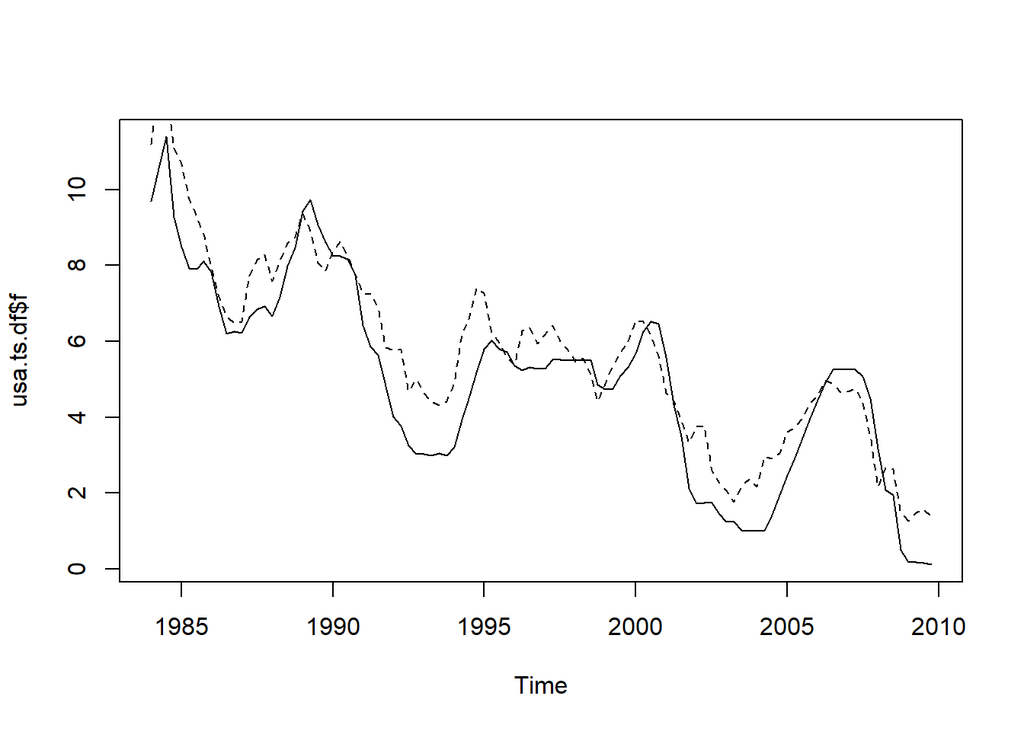

```r
usa.ts <- ts(usa, start=c(1984,1), end=c(2009,4),
               frequency=4)
Dgdp <- diff(usa.ts[,1])
Dinf <- diff(usa.ts[,"inf"])
Df <- diff(usa.ts[,"f"])
Db <- diff(usa.ts[,"b"])
usa.ts.df <- ts.union(gdp=usa.ts[,1], # package tseries
                      inf=usa.ts[,2],
                      f=usa.ts[,3],
                      b=usa.ts[,4],
                      Dgdp,Dinf,Df,Db,
                      dframe=TRUE)

plot(usa.ts.df$f)
points(usa.ts.df$b,type="l",lty=2)
```

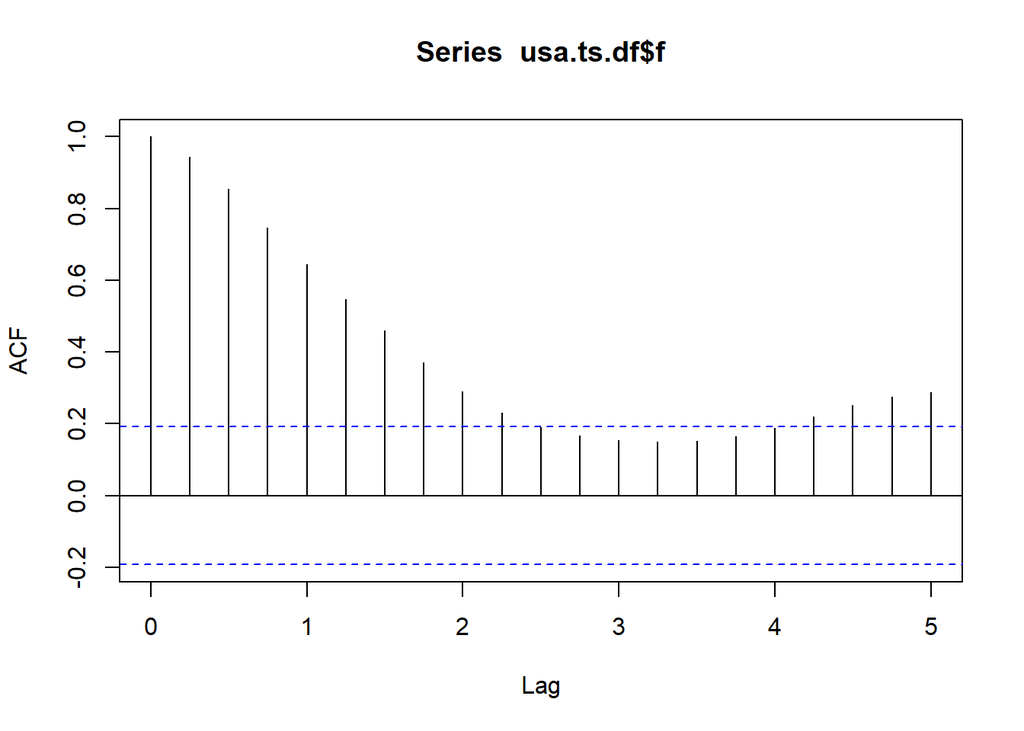

```r
acf(usa.ts.df$f)
```

```r
adf.test(usa.ts.df$f, k=10)
```

```
##
##  Augmented Dickey-Fuller Test
##
## data:  usa.ts.df$f
## Dickey-Fuller = -3.3726, Lag order = 10, p-value = 0.06283
## alternative hypothesis: stationary
```

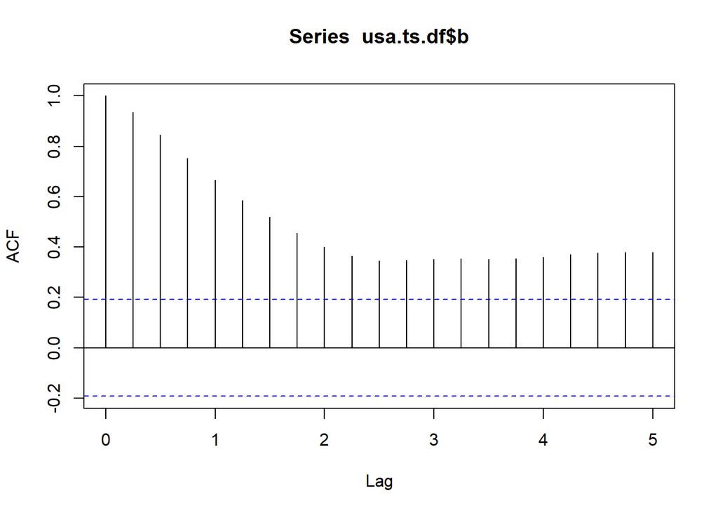

```r
acf(usa.ts.df$b)
```

```r
adf.test(usa.ts.df$b, k=10)
```

```
##
##  Augmented Dickey-Fuller Test
##
## data:  usa.ts.df$b
## Dickey-Fuller = -2.9838, Lag order = 10, p-value = 0.1687
## alternative hypothesis: stationary
```

```r
fb.dyn <- dynlm(usa.ts.df$b~usa.ts.df$f)
ehat.fb <- resid(fb.dyn)
adf.test(ehat.fb)
```

```
##
##  Augmented Dickey-Fuller Test
##
## data:  ehat.fb
## Dickey-Fuller = -4.0009, Lag order = 4, p-value = 0.01184
## alternative hypothesis: stationary
```

```r
test=ur.df(ehat.fb,type="trend",lags = 4)
summary(test)
```

```
##
## ###############################################
## # Augmented Dickey-Fuller Test Unit Root Test #
## ###############################################
##
## Test regression trend
##
##
## Call:
## lm(formula = z.diff ~ z.lag.1 + 1 + tt + z.diff.lag)
##
## Residuals:
##     Min      1Q  Median      3Q     Max
## -0.8577 -0.2790 -0.0320  0.2075  1.1325
##
## Coefficients:
##             Estimate Std. Error t value Pr(>|t|)
## (Intercept)  0.10356    0.09883   1.048 0.297445
## z.lag.1     -0.31001    0.07748  -4.001 0.000127 ***
## tt          -0.00242    0.00169  -1.432 0.155511
## z.diff.lag1  0.36889    0.09844   3.747 0.000312 ***
## z.diff.lag2 -0.01423    0.10540  -0.135 0.892884
## z.diff.lag3  0.21686    0.09715   2.232 0.028021 *
## z.diff.lag4 -0.07490    0.09910  -0.756 0.451713
## ---
## Signif. codes:  0 '***' 0.001 '**' 0.01 '*' 0.05 '.' 0.1 ' ' 1
##
## Residual standard error: 0.4027 on 92 degrees of freedom
## Multiple R-squared:  0.2577, Adjusted R-squared:  0.2093
## F-statistic: 5.323 on 6 and 92 DF,  p-value: 9.43e-05
##
##
## Value of test-statistic is: -4.0009 5.6324 8.3633
##
## Critical values for test statistics:
##       1pct  5pct 10pct
## tau3 -3.99 -3.43 -3.13
## phi2  6.22  4.75  4.07
## phi3  8.43  6.49  5.47
```

```r
test=ur.df(ehat.fb,type="none",lags = 1)
summary(test)
```

```
##
## ###############################################
## # Augmented Dickey-Fuller Test Unit Root Test #
## ###############################################
##
## Test regression none
##
##
## Call:
## lm(formula = z.diff ~ z.lag.1 - 1 + z.diff.lag)
##
## Residuals:
##      Min       1Q   Median       3Q      Max
## -0.91006 -0.31171 -0.08908  0.18918  1.10640
##
## Coefficients:
##            Estimate Std. Error t value Pr(>|t|)
## z.lag.1     -0.2245     0.0535  -4.196 5.89e-05 ***
## z.diff.lag   0.2540     0.0937   2.711  0.00789 **
## ---
## Signif. codes:  0 '***' 0.001 '**' 0.01 '*' 0.05 '.' 0.1 ' ' 1
##
## Residual standard error: 0.4173 on 100 degrees of freedom
## Multiple R-squared:  0.1689, Adjusted R-squared:  0.1523
## F-statistic: 10.16 on 2 and 100 DF,  p-value: 9.598e-05
##
##
## Value of test-statistic is: -4.1961
##
## Critical values for test statistics:
##       1pct  5pct 10pct
## tau1 -2.58 -1.95 -1.62
```

In conclusion, we reject the null hypothesis that the residuals have unit roots, therefore the series are cointegrated.

R has a special function to perform cointegration tests, function po.test in package tseries. (The name comes from the method it uses, which is called “Phillips-Ouliaris.”) The main argument of the function is a matrix having in its first column the dependent variable of the cointegration equation and the independent variables in the other columns. Let me illustrate its application in the case of the same series fb and f .

```r
bfx <- as.matrix(cbind(usa.ts.df$b,usa.ts.df$f), demean=FALSE)
po.test(bfx)
```

```
##
##  Phillips-Ouliaris Cointegration Test
##
## data:  bfx
## Phillips-Ouliaris demeaned = -20.508, Truncation lag parameter =
## 1, p-value = 0.04986
```

The PO test marginally rejects the null of no cointegration at the 5 percent level.

# 3 Vector Error Correction

If two I(1) time series $Z_t$ and $Y_t$ are cointegrated, their differences are stationary and can be modeled in a VAR which is augmented by the regressor $Z_{t−1}− \beta_0 - \beta_1 Y_{t−1}$. This is called a vector error correction model (VEC) and $Z_t − \beta_0 - \beta_1 Y_t$ is called the error correction term. Lagged values of the error correction term are useful for predicting $\nabla Z_t$ and/or $\nabla Y_t$.

$$\nabla Z_t = c_1 + \gamma (Z_{t−1}− \beta_0 - \beta_1 Y_{t−1}) + a_{1,t}\\
\nabla Y_t = c_2 + \gamma (Z_{t−1}− \beta_0 - \beta_1 Y_{t−1}) + a_{2,t}$$

**Example**

The dataset `gdp` , which includes real GDP series for Australia and USA for the period since 1970:Q1 to 2000:Q4. First we determine the order of integration of the two series.

```r
load("gdp.rda")
gdp
```

```
##          usa      aus
## 1    38.3011  38.2355
## 2    38.3734  38.7551
## 3    38.7137  38.7706
## 4    38.2991  38.8948
## 5    39.3615  39.5621
## 6    39.5836  39.6402
## 7    39.8973  40.8614
## 8    40.0114  40.6741
## 9    40.7224  40.2642
## 10   41.6840  41.1712
## 11   42.0813  40.9545
## 12   42.7699  41.4527
## 13   43.8558  42.2458
## 14   44.3631  42.5829
```

[output cut: 110 more lines]

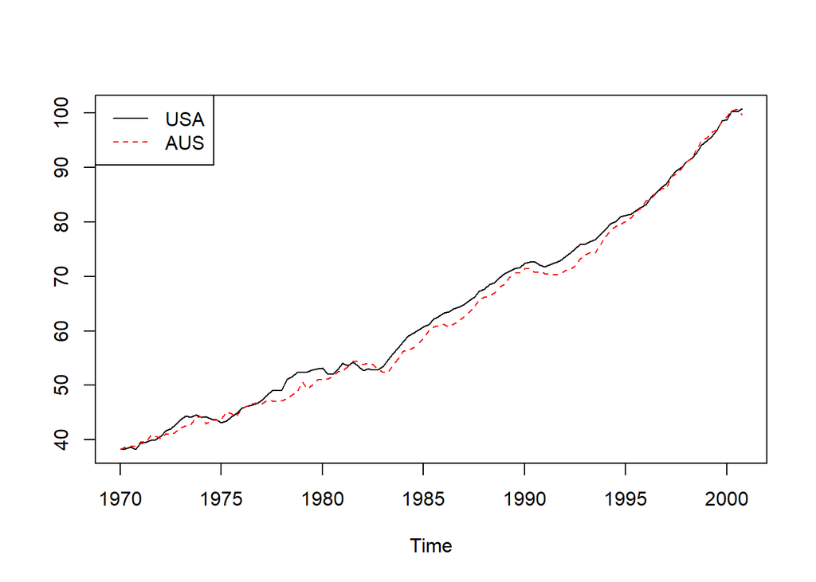

```r
gdp <- ts(gdp, start=c(1970,1), end=c(2000,4), frequency=4)

ts.plot(gdp[,"usa"],gdp[,"aus"], type="l",
        lty=c(1,2), col=c(1,2))
legend("topleft", border=NULL, legend=c("USA","AUS"),
       lty=c(1,2), col=c(1,2))
```

The two series in levels reveal a common trend and, therefore, suggest that the series are nonstationary.

```r
adf.test(gdp[,"usa"])
```

```
##
##  Augmented Dickey-Fuller Test
##
## data:  gdp[, "usa"]
## Dickey-Fuller = -0.90827, Lag order = 4, p-value = 0.9492
## alternative hypothesis: stationary
```

```r
adf.test(gdp[,"aus"])
```

```
##
##  Augmented Dickey-Fuller Test
##
## data:  gdp[, "aus"]
## Dickey-Fuller = -0.61238, Lag order = 4, p-value = 0.9755
## alternative hypothesis: stationary
```

```r
adf.test(diff(gdp[,"usa"]))
```

```
##
##  Augmented Dickey-Fuller Test
##
## data:  diff(gdp[, "usa"])
## Dickey-Fuller = -4.2929, Lag order = 4, p-value = 0.01
## alternative hypothesis: stationary
```

```r
adf.test(diff(gdp[,"aus"]))
```

```
##
##  Augmented Dickey-Fuller Test
##
## data:  diff(gdp[, "aus"])
## Dickey-Fuller = -4.4168, Lag order = 4, p-value = 0.01
## alternative hypothesis: stationary
```

The stationarity tests indicate that both series are I(1), Let us now test them for cointegration. We regression `aus` on `usa` to obtain the residuals and check its stationarity.

```r
cint1.dyn <- dynlm(aus~usa-1, data=gdp)
summary(cint1.dyn)
```

```
##
## Time series regression with "ts" data:
## Start = 1970(1), End = 2000(4)
##
## Call:
## dynlm(formula = aus ~ usa - 1, data = gdp)
##
## Residuals:
##      Min       1Q   Median       3Q      Max
## -2.72821 -1.06932 -0.08543  0.91592  2.26603
##
## Coefficients:
##     Estimate Std. Error t value Pr(>|t|)
## usa 0.985350   0.001657   594.8   <2e-16 ***
## ---
## Signif. codes:  0 '***' 0.001 '**' 0.01 '*' 0.05 '.' 0.1 ' ' 1
##
## Residual standard error: 1.219 on 123 degrees of freedom
## Multiple R-squared:  0.9997, Adjusted R-squared:  0.9996
## F-statistic: 3.538e+05 on 1 and 123 DF,  p-value: < 2.2e-16
```

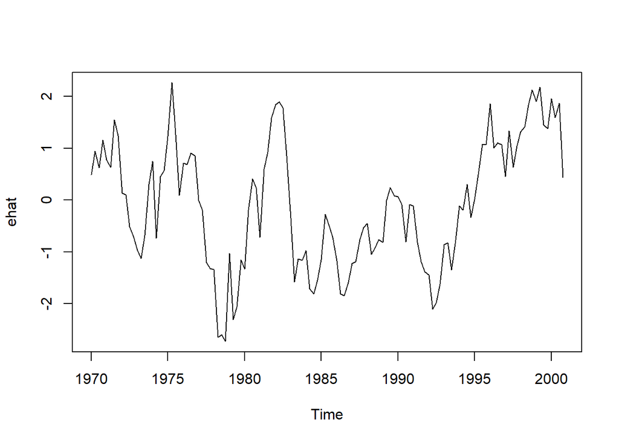

```r
ehat <- resid(cint1.dyn)
plot(ehat)
```

```r
adf.test(ehat)
```

```
##
##  Augmented Dickey-Fuller Test
##
## data:  ehat
## Dickey-Fuller = -2.7767, Lag order = 4, p-value = 0.2538
## alternative hypothesis: stationary
```

```r
summary(ur.df(ehat,type="trend",lags = 4))
```

```
##
## ###############################################
## # Augmented Dickey-Fuller Test Unit Root Test #
## ###############################################
##
## Test regression trend
##
##
## Call:
## lm(formula = z.diff ~ z.lag.1 + 1 + tt + z.diff.lag)
##
## Residuals:
##     Min      1Q  Median      3Q     Max
## -1.4582 -0.3237  0.0162  0.3902  1.4508
##
## Coefficients:
##              Estimate Std. Error t value Pr(>|t|)
## (Intercept) -0.124966   0.122120  -1.023  0.30837
## z.lag.1     -0.149378   0.053796  -2.777  0.00644 **
## tt           0.001642   0.001676   0.979  0.32951
## z.diff.lag1  0.011419   0.097235   0.117  0.90673
## z.diff.lag2  0.055311   0.096916   0.571  0.56934
## z.diff.lag3  0.072081   0.096755   0.745  0.45784
## z.diff.lag4 -0.057948   0.096178  -0.603  0.54805
## ---
## Signif. codes:  0 '***' 0.001 '**' 0.01 '*' 0.05 '.' 0.1 ' ' 1
##
## Residual standard error: 0.6127 on 112 degrees of freedom
## Multiple R-squared:  0.08504,    Adjusted R-squared:  0.03602
## F-statistic: 1.735 on 6 and 112 DF,  p-value: 0.1193
##
##
## Value of test-statistic is: -2.7767 2.658 3.9866
##
## Critical values for test statistics:
##       1pct  5pct 10pct
## tau3 -3.99 -3.43 -3.13
## phi2  6.22  4.75  4.07
## phi3  8.43  6.49  5.47
```

```r
summary(ur.df(ehat,type="drift",lags = 4))
```

```
##
## ###############################################
## # Augmented Dickey-Fuller Test Unit Root Test #
## ###############################################
##
## Test regression drift
##
##
## Call:
## lm(formula = z.diff ~ z.lag.1 + 1 + z.diff.lag)
##
## Residuals:
##      Min       1Q   Median       3Q      Max
## -1.49763 -0.33712  0.01271  0.38747  1.43283
##
## Coefficients:
##             Estimate Std. Error t value Pr(>|t|)
## (Intercept) -0.01898    0.05657  -0.335  0.73790
## z.lag.1     -0.14038    0.05300  -2.649  0.00923 **
## z.diff.lag1  0.01405    0.09718   0.145  0.88530
## z.diff.lag2  0.05693    0.09688   0.588  0.55799
## z.diff.lag3  0.07521    0.09668   0.778  0.43824
## z.diff.lag4 -0.05722    0.09616  -0.595  0.55296
## ---
## Signif. codes:  0 '***' 0.001 '**' 0.01 '*' 0.05 '.' 0.1 ' ' 1
##
## Residual standard error: 0.6126 on 113 degrees of freedom
## Multiple R-squared:  0.0772, Adjusted R-squared:  0.03637
## F-statistic: 1.891 on 5 and 113 DF,  p-value: 0.1014
##
##
## Value of test-statistic is: -2.6489 3.5086
##
## Critical values for test statistics:
##       1pct  5pct 10pct
## tau2 -3.46 -2.88 -2.57
## phi1  6.52  4.63  3.81
```

```r
summary(ur.df(ehat,type="none",lags = 4))
```

```
##
## ###############################################
## # Augmented Dickey-Fuller Test Unit Root Test #
## ###############################################
##
## Test regression none
##
##
## Call:
## lm(formula = z.diff ~ z.lag.1 - 1 + z.diff.lag)
##
## Residuals:
##      Min       1Q   Median       3Q      Max
## -1.51392 -0.35572 -0.00387  0.36798  1.41733
##
## Coefficients:
##             Estimate Std. Error t value Pr(>|t|)
## z.lag.1     -0.13830    0.05243  -2.638  0.00951 **
## z.diff.lag1  0.01255    0.09670   0.130  0.89695
## z.diff.lag2  0.05532    0.09639   0.574  0.56712
## z.diff.lag3  0.07362    0.09619   0.765  0.44564
## z.diff.lag4 -0.05866    0.09569  -0.613  0.54107
## ---
## Signif. codes:  0 '***' 0.001 '**' 0.01 '*' 0.05 '.' 0.1 ' ' 1
##
## Residual standard error: 0.6102 on 114 degrees of freedom
## Multiple R-squared:  0.0763, Adjusted R-squared:  0.03579
## F-statistic: 1.883 on 5 and 114 DF,  p-value: 0.1026
##
##
## Value of test-statistic is: -2.638
##
## Critical values for test statistics:
##       1pct  5pct 10pct
## tau1 -2.58 -1.95 -1.62
```

Our test rejects the null of no cointegration, meaning that the series are cointegrated. With cointegrated series we can construct a VEC model to better understand the causal relationship between the two variables.

```r
vecaus<- dynlm(d(aus)~L(ehat), data=gdp)
vecusa <- dynlm(d(usa)~L(ehat), data=gdp)
summary(vecaus)
```

```
##
## Time series regression with "ts" data:
## Start = 1970(2), End = 2000(4)
##
## Call:
## dynlm(formula = d(aus) ~ L(ehat), data = gdp)
##
## Residuals:
##      Min       1Q   Median       3Q      Max
## -1.82072 -0.41633  0.01881  0.41823  1.73368
##
## Coefficients:
##             Estimate Std. Error t value Pr(>|t|)
## (Intercept)  0.49171    0.05791   8.491 6.12e-14 ***
## L(ehat)     -0.09870    0.04752  -2.077   0.0399 *
## ---
## Signif. codes:  0 '***' 0.001 '**' 0.01 '*' 0.05 '.' 0.1 ' ' 1
##
## Residual standard error: 0.6409 on 121 degrees of freedom
## Multiple R-squared:  0.03443,    Adjusted R-squared:  0.02645
## F-statistic: 4.315 on 1 and 121 DF,  p-value: 0.03989
```

```r
summary(vecusa)
```

```
##
## Time series regression with "ts" data:
## Start = 1970(2), End = 2000(4)
##
## Call:
## dynlm(formula = d(usa) ~ L(ehat), data = gdp)
##
## Residuals:
##      Min       1Q   Median       3Q      Max
## -1.54329 -0.30388  0.03483  0.36117  1.47005
##
## Coefficients:
##             Estimate Std. Error t value Pr(>|t|)
## (Intercept)  0.50988    0.04668   10.92   <2e-16 ***
## L(ehat)      0.03025    0.03830    0.79    0.431
## ---
## Signif. codes:  0 '***' 0.001 '**' 0.01 '*' 0.05 '.' 0.1 ' ' 1
##
## Residual standard error: 0.5166 on 121 degrees of freedom
## Multiple R-squared:  0.005129,   Adjusted R-squared:  -0.003093
## F-statistic: 0.6238 on 1 and 121 DF,  p-value: 0.4312
```

The coefficient on the error correction term ( `L(ehat)` ) is significant for Australia, suggesting that changes in the US economy do affect Australian economy; the error correction coefficient in the US equation is not statistically significant, suggesting that changes in Australia do not influence American economy. To interpret the sign of the error correction coefficient, one should remember that the residual measures the deviation of Australian economy from its cointegrating level of 0.985 of the US economy (see the value of the slope in `cint1.dyn`).

# 4 VAR as a Solution to Non-cointegrated Time Series

On the other hand, the VAR model can be used when the two variables $Z_t$ and $Y_t$ under study are I(1) but not cointegrated. Here is an example.

Let us look at the income-consumption relationship based on the fred detaset, where consumption and income are already in logs, and the period is 1960:Q1 to 2009:Q4. 200 observations on the following 2 variables: `c`, log of real consumption expenditure; `y`, log of real disposable income.

```r
load("fred.rda")
fred
```

```
##            c        y
## 1   7.479017 7.578401
## 2   7.491590 7.583807
## 3   7.487622 7.584671
## 4   7.488965 7.584061
## 5   7.488685 7.593122
## 6   7.503455 7.608077
## 7   7.508294 7.621636
## 8   7.528117 7.641084
## 9   7.538708 7.650502
## 10  7.550924 7.661621
## 11  7.558986 7.667158
## 12  7.573069 7.675360
## 13  7.579781 7.683634
## 14  7.589285 7.693071
```

[output cut: 186 more lines]

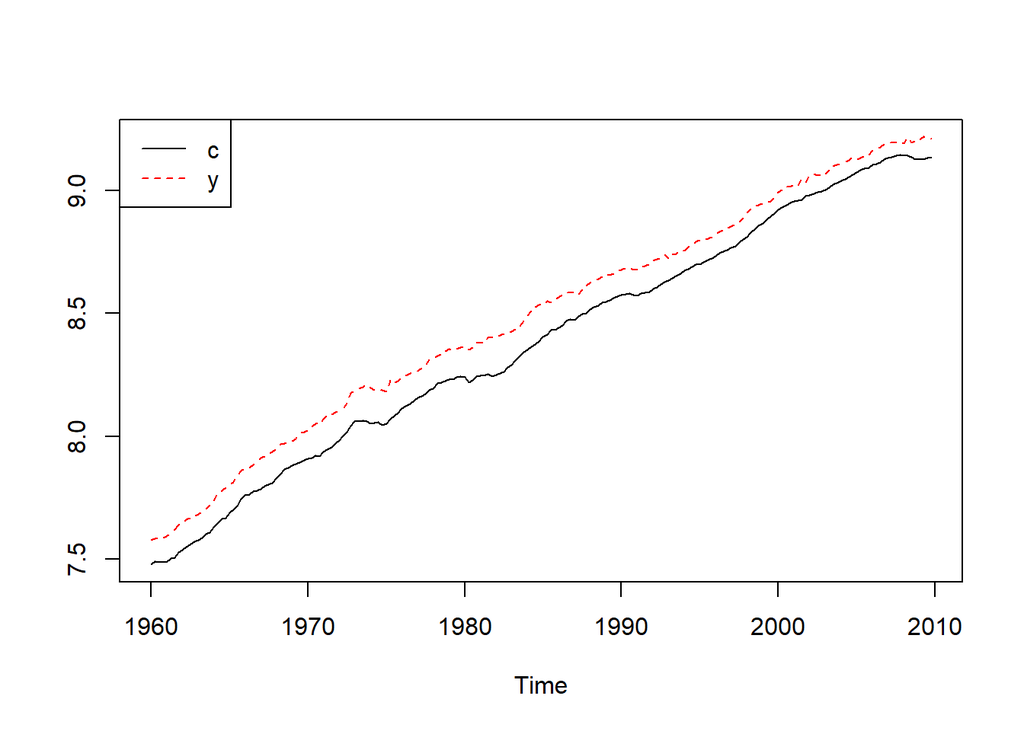

```r
fred <- ts(fred, start=c(1960,1),end=c(2009,4),frequency=4)
ts.plot(fred[,"c"],fred[,"y"], type="l",
        lty=c(1,2), col=c(1,2))
legend("topleft", border=NULL, legend=c("c","y"),
       lty=c(1,2), col=c(1,2))
```

Are the two series cointegrated?

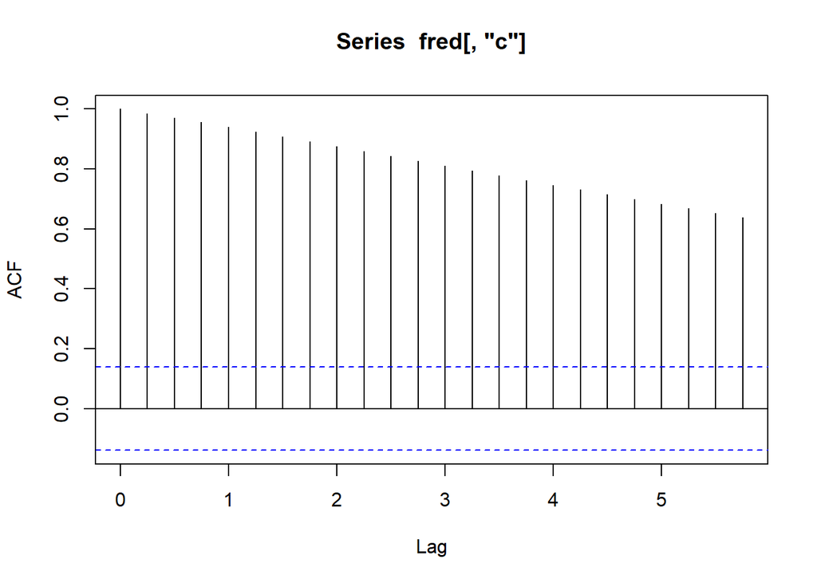

```r
acf(fred[,"c"])
```

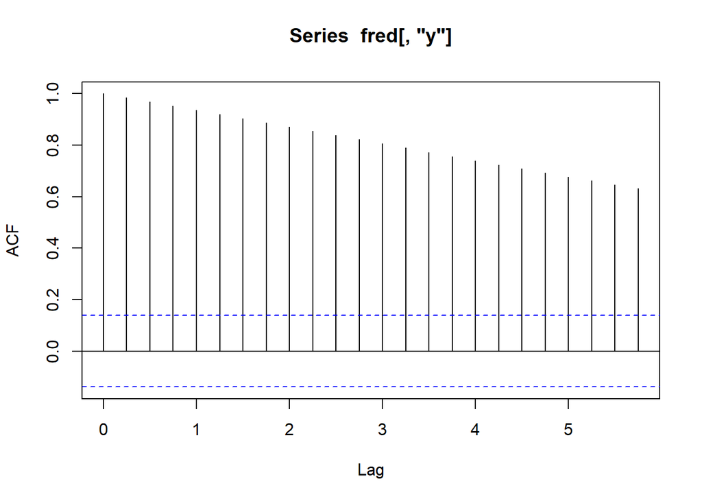

```r
acf(fred[,"y"])
```

```r
adf.test(fred[,"c"])
```

```
##
##  Augmented Dickey-Fuller Test
##
## data:  fred[, "c"]
## Dickey-Fuller = -2.6202, Lag order = 5, p-value = 0.3163
## alternative hypothesis: stationary
```

```r
adf.test(fred[,"y"])
```

```
##
##  Augmented Dickey-Fuller Test
##
## data:  fred[, "y"]
## Dickey-Fuller = -2.2905, Lag order = 5, p-value = 0.4544
## alternative hypothesis: stationary
```

```r
adf.test(diff(fred[,"c"]))
```

```
##
##  Augmented Dickey-Fuller Test
##
## data:  diff(fred[, "c"])
## Dickey-Fuller = -4.713, Lag order = 5, p-value = 0.01
## alternative hypothesis: stationary
```

```r
adf.test(diff(fred[,"y"]))
```

```
##
##  Augmented Dickey-Fuller Test
##
## data:  diff(fred[, "y"])
## Dickey-Fuller = -5.7751, Lag order = 5, p-value = 0.01
## alternative hypothesis: stationary
```

```r
cointcy <- dynlm(c~y, data=fred)
ehat <- resid(cointcy)
adf.test(ehat)
```

```
##
##  Augmented Dickey-Fuller Test
##
## data:  ehat
## Dickey-Fuller = -2.5617, Lag order = 5, p-value = 0.3409
## alternative hypothesis: stationary
```

Figure shows a long serial correlation sequence; therefore, I will let R calculate the lag order in the ADF test. As the results of the above adf and cointegration tests show, the series are both I(1) but they fail the cointegration test (the series are not cointegrated.) (Please rememebr that the adf.test function uses a constant and trend in the test equation; therefore, the critical values are not the same as in the textbook. However, the results of the tests should be the same most of the time.)

```r
Dc <- diff(fred[,"c"])
Dy <- diff(fred[,"y"])
varmat <- as.matrix(cbind(Dc,Dy))
varfit <- VAR(varmat) # `VAR()` from package `vars`
summary(varfit)
```

```
##
## VAR Estimation Results:
## =========================
## Endogenous variables: Dc, Dy
## Deterministic variables: const
## Sample size: 198
## Log Likelihood: 1400.444
## Roots of the characteristic polynomial:
## 0.3441 0.3425
## Call:
## VAR(y = varmat)
##
##
## Estimation results for equation Dc:
## ===================================
## Dc = Dc.l1 + Dy.l1 + const
##
##        Estimate Std. Error t value Pr(>|t|)
## Dc.l1 0.2156068  0.0747486   2.884  0.00436 **
## Dy.l1 0.1493798  0.0577343   2.587  0.01040 *
## const 0.0052776  0.0007573   6.969 4.81e-11 ***
## ---
## Signif. codes:  0 '***' 0.001 '**' 0.01 '*' 0.05 '.' 0.1 ' ' 1
##
##
## Residual standard error: 0.006575 on 195 degrees of freedom
## Multiple R-Squared: 0.1205,  Adjusted R-squared: 0.1115
## F-statistic: 13.36 on 2 and 195 DF,  p-value: 3.661e-06
##
##
## Estimation results for equation Dy:
## ===================================
## Dy = Dc.l1 + Dy.l1 + const
##
##         Estimate Std. Error t value Pr(>|t|)
## Dc.l1  0.4754276  0.0973264   4.885 2.15e-06 ***
## Dy.l1 -0.2171679  0.0751730  -2.889   0.0043 **
## const  0.0060367  0.0009861   6.122 4.99e-09 ***
## ---
## Signif. codes:  0 '***' 0.001 '**' 0.01 '*' 0.05 '.' 0.1 ' ' 1
##
##
## Residual standard error: 0.008562 on 195 degrees of freedom
## Multiple R-Squared: 0.1118,  Adjusted R-squared: 0.1027
## F-statistic: 12.27 on 2 and 195 DF,  p-value: 9.53e-06
##
##
##
## Covariance matrix of residuals:
##           Dc        Dy
## Dc 4.324e-05 2.508e-05
## Dy 2.508e-05 7.330e-05
##
## Correlation matrix of residuals:
##        Dc     Dy
## Dc 1.0000 0.4456
## Dy 0.4456 1.0000
```

Function VAR(), which is part of the package vars (Pfaff 2013), accepts the following main arguments: y= a matrix containing the endogenous variables in the VAR model, p= the desired lag order (default is 1), and exogen= a matrix of exogenous variables. (VAR is a more powerful instrument than I imply here; please type ?VAR() for more information.)

# 5 Spurious Regression

Nonstationarity can lead to spurious regression, an apparent relationship between variables that are, in reality not related. The following code sequence generates two independent random walk processes, y and x , and regresses y on x .

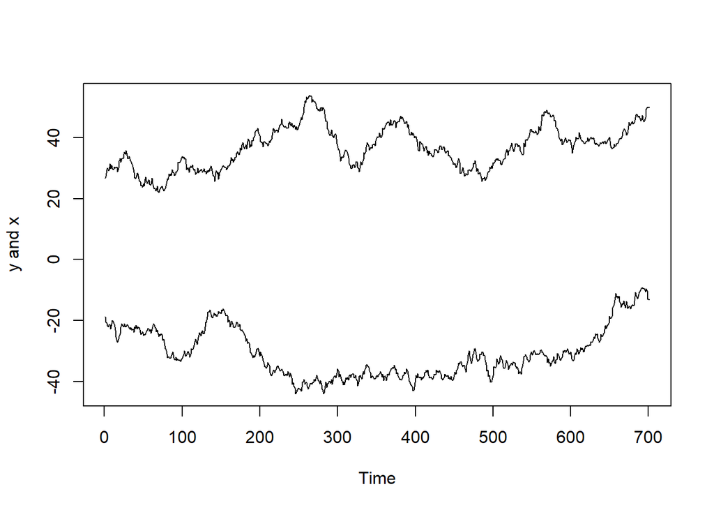

```r
T <- 1000
set.seed(1357)
y <- ts(rep(0,T))
vy <- ts(rnorm(T))
for (t in 2:T){
  y[t] <- y[t-1]+vy[t]
}

set.seed(4365)
x <- ts(rep(0,T))
vx <- ts(rnorm(T))
for (t in 2:T){
  x[t] <- x[t-1]+vx[t]
}
y <- ts(y[300:1000])
x <- ts(x[300:1000])
ts.plot(y,x, ylab="y and x")
```

```r
spurious.ols <- lm(y~x)
summary(spurious.ols)
```

```
##
## Call:
## lm(formula = y ~ x)
##
## Residuals:
##     Min      1Q  Median      3Q     Max
## -12.554  -5.973  -2.453   4.508  24.678
##
## Coefficients:
##              Estimate Std. Error t value Pr(>|t|)
## (Intercept) -20.38711    1.61958 -12.588  < 2e-16 ***
## x            -0.28188    0.04331  -6.508 1.45e-10 ***
## ---
## Signif. codes:  0 '***' 0.001 '**' 0.01 '*' 0.05 '.' 0.1 ' ' 1
##
## Residual standard error: 7.954 on 699 degrees of freedom
## Multiple R-squared:  0.05713,    Adjusted R-squared:  0.05578
## F-statistic: 42.35 on 1 and 699 DF,  p-value: 1.454e-10
```

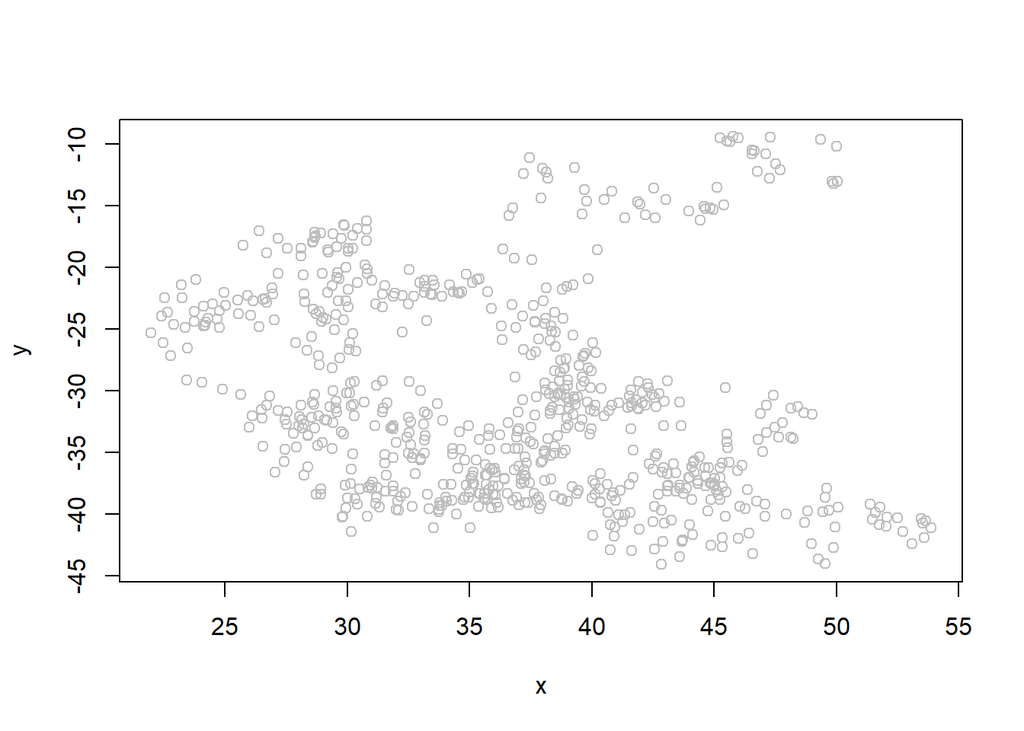

```r
plot(x, y, type="p", col="grey")
```